# Lecture: Choosing between pre-implemented and custom solutions

## 1 Developing your own Stan models

### 1.1 Motivation

- We have now illustrated how we can continuously expand the complexity of a Stan model.
- However, so far, we have dealt with standard hierarchical models that one could equally estimate using a ‘canned solution’.
- At some point, however, you will likely want to push past the boundaries of such canned solutions.
- Below are some motivating examples.

### 1.2 Relaxing model assumptions

- You estimate a hierarchical GLM with random intercepts and few groups.
- Reviewer 2 has read up on some recent publications (e.g., [Stegmueller 2013](https://onlinelibrary.wiley.com/doi/full/10.1111/ajps.12001); [Elff et al. 2020](https://www.elff.eu/article/multilevel-improving/)) and criticizes your use of normally distributed random effects.
- You can use Stan (or `brms`) to relax these assumptions.
- You may, e.g., reestimate your model with different distributions for your random effects, and conduct simulation studies to test their relative performance towards one another.

### 1.3 Heterogeneous treatment effects

- You conduct an RCT with a binary treatment on political attitudes.
- You use a standard difference-in-means estimator, which yields a null effect.
- This is in line with your expectations, as you expect that the treatment will “shift” some individuals to the left, others to the right.
- You cannot accurately characterize left-shifters an right-shifters in terms of covariates and, therefore, not present meaningful subgroup-specific difference-in-means estimates.
- Why not focus on the variance, then?
- Use Stan to implement a “difference-in-variances” estimator. Use the posterior distribution for inference on the question if your treatment polarizes political attitudes among treated individuals relative to control units.

### 1.4 Re-running (and extending) models written in defunct or proprietary programming languages

- In *When Moderate Voters Prefer Extreme Parties*, [Kedar (2005)](https://www.cambridge.org/core/journals/american-political-science-review/article/when-moderate-voters-prefer-extreme-parties-policy-balancingin-parliamentary-elections/A6729F56D47DDD3993DD3CA02840B6B0) proposes a formal model for representational (sincere) and compensational (strategic) voting.
- The model involves a mixing parameter, $\beta$:
  $$u_{ij} = \theta [-\beta \times
  \text{representational}_{ij} - (1 - \beta) \times
  \text{compensational}_{ij}] + \mathbf{z}_{i}^{\prime}\delta_j$$
- The empirical analyses implement this idea in a conditional logit model with a constrained mixing parameter, $\beta \in [0,1]$, and coded up in GAUSS.
- Why not implement this model in Stan?
- Why not transfer the idea of a mixing parameter to a different type of model?
- Why not extend the idea of a mixing parameter from two to three (or more) components, and allow it to vary? One example: A trivariate heterogeneous mixing parameter that tests how consistently policy distances on (1) socio-economic issues, (2) immigration, and (3) climate change affect vote choices for voters of different generations?

### 1.5 Custom solutions for custom problems

- You want to build a polling aggregator for parties’ poll shares in Germany, 2021-2025.
- Specifically, you want to model the week-to-week evolution of parties’ vote shares, incorporating the uncertainty that arises from each poll and from their joint aggregation.
- You want to get several things right:
  - Contrast suitable generative models (e.g., a Dirichlet model for the reported shares or a multinomial model for the polled respondent counts)
  - Impose a model for the latent temporal evolution of the vote shares, e.g., as random walk
  - Purge the predictions from ‘pollster’ effects
  - Accommodate idiosyncrasy: In January 2024, a new competitor enters the party system—its share must be deterministically zero until then, and modeled after its entry

### 1.6 An example from my own research: Modeling comparative vote switching

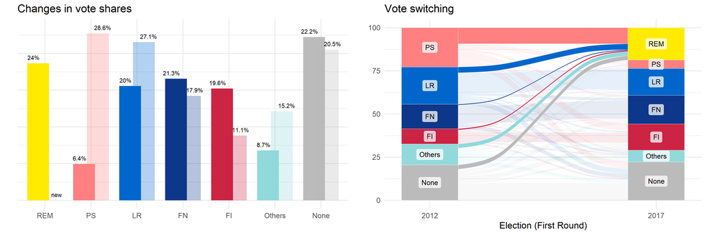

### 1.7 Voter transition matrices

Voter transition matrix, UK General Elections 2005-2010.

|  | LAB ’10 | LIB ’10 | CON ’10 | OTH ’10 | NON ’10 | 2005 |
| --- | --- | --- | --- | --- | --- | --- |
| LAB ’05 | 12.7 | 2.3 | 2.1 | 0.7 | 3.8 | 21.6 |
| LIB ’05 | 1.4 | 8.7 | 1.7 | 0.4 | 1.2 | 13.5 |
| CON ’05 | 0.8 | 1.0 | 15.0 | 1.0 | 2.0 | 19.9 |
| OTH ’05 | 0.2 | 0.7 | 0.6 | 3.5 | 1.3 | 6.4 |
| NON ’05 | 3.7 | 2.2 | 4.0 | 2.2 | 26.5 | 38.6 |
| 2010 | 18.9 | 15.0 | 23.5 | 7.7 | 34.9 | 100.0 |

#### 1.7.1 Basic quantities of interest

1. *Party-specific retention rates*, $p_{i,i}$
2. *Dyadic gross gains/losses*, $p_{i,j}$
3. *Dyadic trade volumes*, $V_{i,j} = p_{j,i} + p_{i,j}$
4. *Dyadic trade balances*, $V_{i,j} = p_{j,i} - p_{i,j}$

### 1.8 Mixed Aggregate MNL Model with Varying Choice Sets (MAVCL)

#### 1.8.1 Description

MAVCL models latent election-level *cell proportions*, $\Pr(y_{j} = c)$, derived as average micro-level *choice probabilities*, based on cell counts, $w_{jc}$:

- A categorical likelihood at the voter level models individual *choice probabilities* (as in MNL).
- As the model only involves election-level covariates, we can re-express this model at the election-level with $w_{jc}$’s serve as election-and-cell-specific frequency weights. This yields a multinomial quasi-likelihood at the election-level.
- Here, election-cell-specific random effects capture variation of interest: Latent election-specific *cell proportions*.
- Party system heterogeneity yields election-specific choice sets $S_j = \{1,...,C\}$
  - some outcomes categories $c$ will be deterministically empty
  - accommodated in a modified softmax link function (see Yamamoto 2014)

#### 1.8.2 Formal notation

- Linear component: $\eta_{jc} = \alpha_c + \mathbf{x}_j^{\prime} \beta_c + \nu_{jc} \text{ for each } c \in S_{j}$
- Link function: $\Pr(y_{j} = c | \mathbf{x}_j) = \frac{\exp(\eta_{jc})}{\sum_{c \in S_{j}} \exp(\eta_{jc})}$
- Likelihood: $\log L = \sum_{j=1}^{J} \sum_{c \in S_{j}} w_{jc} \log \Pr(y_{j} = c | \mathbf{x}_j)$

### 1.9 Software implementation

[interactive chart not shown]

## 2 Take-aways for aspiring model developers

### 2.1 Determine if a ‘canned solution’ already exists.

1. It exists and accomplishes exactly what you want to do? $\rightarrow$ Use it!
2. It exists but falls short of accomplishing *exactly* what you want to do? $\rightarrow$ Build up on it!
3. It doesn’t exist? $\rightarrow$ Build your own model! Note that while it may seem like you are starting from scratch, but most likely, many parts of your model will resemble existing (Stan) models.

### 2.2 Moving beyond ‘canned solutions’

1. Choose the correct likelihood for your model. Stan will almost certainly feature the required log probability function. If it doesn’t, translate the mathematical log-likelihood function to a custom `lpmf`/`lpdf` function.
2. Think about the “right-hand side” of your model formula (i.e., systematic component and inverse link). Start simple, increase flexibility step-wise.
3. Use the documentation and the vast online resources. Seek help when necessary.
4. Once your model runs: Validate it.
5. Once validated, move on to inference. Carefully diagnose your model!

### 2.3 Computational problems

Suppose one or several of the following apply:

- Your algorithm-specific diagnostics throw warnings (that don’t go away easily)
- Your convergence diagnostics indicate signs of non-convergence (and increasing the warm-up period doesn’t help)
- Everything converges, but you get non-sensical estimates and predictions
- You are confident that your model will eventually converge to a well-behaved target distribution but it takes *forever* and even lengthy runs won’t get you there (yet).

Then what?

### 2.4 Addressing computational problems

Gelman et al. (2020) have some answers:

### 2.5 Check for model misspecification

- Is the probability model correctly specified?
- Are constraints set adequately?
- Do your priors allow for posterior density in regions where you’d expect it?
- Are your parameters statistically identified?

### 2.6 When a complex model fails: Reduce complexity

- Suppose you fit a mixture model with two equations, a constrained probabilistic mixing parameter, and various random effects in each equation
- Fit each equation separately without the random effects
- Fit the mixture model without the random effects
- Fit each equation with random effects

### 2.7 Be time-efficient

- Test the model on small sets of well-behaved simulated data
- Test the model using short runs

### 2.8 Efficiency tuning

- Vectorize: Use matrix multiplication instead of loops through matrix rows.
- Reparameterize.
- Standardize data inputs. Increases the chances that your parameters will be on similar scales (which may speed up computation).
- *Alternatively:* Use weakly informative data-dependent priors.
- Make priors more informative (if defensible): Can prevent chains from wandering far off the target distribution.
- Parallelize: Markov chains are independent. Let them run at the same time (if your CPUs allow for it)!

### 2.9 Lastly: Get the most out of your estimates!

- After validation and inference, get the most out of your posterior samples.
- Process your posterior draws into substantively meaningful quantities of interest.
- Visualize whenever possible.